# Práctica

```python
from sklearn.model_selection import train_test_split
import pandas as pd
import numpy as np

full_df = pd.read_csv('./airbnb-listings-extract.csv', sep=';', decimal='.')

full_df.drop(['Listing Url', 'Thumbnail Url', 'Medium Url', 'Picture Url', 'XL Picture Url', 'Host URL', 'Host Thumbnail Url', 'Host Picture Url'], axis = 1, inplace = True)

full_df['City'] = full_df['City'].str.strip()

full_df_madrid = full_df[full_df['City'] == 'Madrid']
print(f'Dimensiones del dataset full: {full_df.shape}')
print(f'Dimensiones del dataset madrid: {full_df_madrid.shape}')
train, test = train_test_split(full_df_madrid, test_size=0.3, shuffle=True, random_state=0) # Con shuffle en True, aseguramos que las muestras pertenecen
                                                                    # a todo el dataset de una forma más o menos proporcional
                                                                    # random_state para usar siempre la misma semilla

print(f'Dimensiones del dataset de training: {train.shape}')
print(f'Dimensiones del dataset de test: {test.shape}')

# Guardamos
train.to_csv('./train.csv', sep=';', decimal='.', index=False)
test.to_csv('./test.csv', sep=';', decimal='.', index=False)

# A partir de este momento cargamos el dataset de train y trabajamos ÚNICAMENTE con él.

df = pd.read_csv('./train.csv', sep=';', decimal='.')
```

```
Dimensiones del dataset full: (14780, 81)
Dimensiones del dataset madrid: (13207, 81)
Dimensiones del dataset de training: (9244, 81)
Dimensiones del dataset de test: (3963, 81)
```

```python
pd.set_option('display.max_columns', None)
df.head(5)
```

|  | ID | Scrape ID | Last Scraped | Name | Summary | Space | Description | Experiences Offered | Neighborhood Overview | Notes | Transit | Access | Interaction | House Rules | Host ID | Host Name | Host Since | Host Location | Host About | Host Response Time | Host Response Rate | Host Acceptance Rate | Host Neighbourhood | Host Listings Count | Host Total Listings Count | Host Verifications | Street | Neighbourhood | Neighbourhood Cleansed | … |
| --- | --- | --- | --- | --- | --- | --- | --- | --- | --- | --- | --- | --- | --- | --- | --- | --- | --- | --- | --- | --- | --- | --- | --- | --- | --- | --- | --- | --- | --- | --- |
| 0 | 9017283 | 20170407214119 | 2017-04-08 | Live&Enjoy La Latina Apartment | Apartamento de planta baja en una calle muy tr... | Los apartamentos recién reformados cuentan con... | Apartamento de planta baja en una calle muy tr... | none | La Latina es el barrio por excelencia de las c... | NaN | El apartamento se encuentra menos de 5 minutos... | Le atenderé 100% durante su estancia en el apa... | Le atenderé 100% durante su estancia en el apa... | No hay muchas normas en la casa mas allá de vi... | 47082976 | Sheila | 2015-10-21 | Madrid, Community of Madrid, Spain | Soy una enamorada de Madrid y de los viajes as... | within an hour | 100.0 | NaN | NaN | 3.0 | 3.0 | phone,reviews | Madrid, Comunidad de Madrid 28005, Spain | NaN | Palacio | … |
| 1 | 7098216 | 20170407214119 | 2017-04-08 | Cozy Studio in Sol - Nice Views | The studio accomodates 3 people and it is perf... | Very nice and luminous studio with a cozy balc... | The studio accomodates 3 people and it is perf... | none | Perfect in Madrid! Sol, Plaza Mayor, Gran Via,... | It is a four floor within lift. | NaN | All of apartment. | I and my friend could provide you maps, tips, ... | Parties are totally prohibited! Take care abou... | 37200202 | Cristina | 2015-07-01 | Spain | Hi, Im Cris!\r\nIm from Alicante and now Im li... | NaN | NaN | NaN | Cortes | 1.0 | 1.0 | email,phone,reviews,jumio | Cortes, Madrid, Comunidad de Madrid 28012, Spain | Cortes | Cortes | … |
| 2 | 17842959 | 20170407214119 | 2017-04-08 | Habitación matrimonial a 20 minutos del centro | Es un piso normal dentro de los predios de mad... | NaN | Es un piso normal dentro de los predios de mad... | none | NaN | NaN | NaN | NaN | NaN | - A partir de las 23:00 silencio | 106263371 | Byron Rolando | 2016-12-05 | Madrid, Community of Madrid, Spain | NaN | within an hour | 100.0 | NaN | Aluche | 4.0 | 4.0 | email,phone,facebook,reviews | Aluche, Madrid, Comunidad de Madrid 28047, Spain | Aluche | Aluche | … |
| 3 | 9205295 | 20170407214119 | 2017-04-08 | Piso agradable rodeado de arte | Acogedor piso en medio del triángulo del arte,... | Encantador espacio que hace sentirte como en c... | Acogedor piso en medio del triángulo del arte,... | none | Ubicado en uno de los barrios con más encanto ... | El piso está en un segundo piso sin ascensor | Para moverte en la cuidad no necesitas más que... | Estudió con baño, tv, wifi, cocina equipada, a... | Los espero en el apartamento a su llegada para... | Respeto a los vecinos y a todo lo que conforma... | 24619741 | Begoña | 2014-12-08 | Madrid, Community of Madrid, Spain | NaN | within an hour | 100.0 | NaN | Cortes | 5.0 | 5.0 | email,phone,reviews,jumio | Madrid, Comunidad de Madrid 28014, Spain | NaN | Cortes | … |
| 4 | 8334816 | 20170407214119 | 2017-04-08 | Apto. Tres habit. Museo Reina Sofía | Frente al Museo Reina Sofía, a cinco minutos a... | NaN | Frente al Museo Reina Sofía, a cinco minutos a... | none | Lavapiés y sus alrededores son el centro neurá... | NaN | Dada la estupenda ubicación del apartamento (9... | NaN | Los horarios de entrada y salida pueden flexib... | Siempre que lo necesitéis no dudéis en consult... | 40668036 | Susana | 2015-08-06 | ES | NaN | within an hour | 100.0 | NaN | NaN | 1.0 | 1.0 | email,phone,reviews,jumio | Madrid, Comunidad de Madrid 28012, Spain | NaN | Embajadores | … |

```python
df.info()
```

```
<class 'pandas.core.frame.DataFrame'>
RangeIndex: 9244 entries, 0 to 9243
Data columns (total 81 columns):
 #   Column                          Non-Null Count  Dtype
---  ------                          --------------  -----
 0   ID                              9244 non-null   int64
 1   Scrape ID                       9244 non-null   int64
 2   Last Scraped                    9244 non-null   object
 3   Name                            9244 non-null   object
 4   Summary                         8911 non-null   object
 5   Space                           6790 non-null   object
 6   Description                     9239 non-null   object
 7   Experiences Offered             9244 non-null   object
 8   Neighborhood Overview           5819 non-null   object
 9   Notes                           3497 non-null   object
```

[output cut: 73 more lines]

En un primer vistazo a las columnas, vemos que hay algunas (además de las urls que ya eliminamos al principio) que pueden no aportarnos valor. También hay algunas que pueden ser redundantes, como Geolocation, Latitude y Longitude respecto al barrio. También hemos visto otras cuya gran mayoría de valores son null y que parece que podrían no aportarnos demasiado valor, como License, Has availability, Host aceptance rate u otras.

Hay varias columnas con prácticamente todos sus valores nulos, por lo que no van a sernos de utilidad. Eliminaremos aquellas con más de la mitad de valores nulos. Mantendremos Square Feet para verla más en profundidad, ya que debería ser relevante.

Hay otras que deberíamos descartar también ya que pueden no contener información objetiva o relevante para el análisis, como Summary, Space o Description. Todas aquellas que son frases (en un análisis mucho más complejo podría haber información relevante por ejemplo, analizando si en aquellas que en House Rules indica que se permiten fiestas incrementa el valor o no, pero estaríamos complejizando mucho el análisis, por lo que descartaremos aquellas que contienen frases para esta tarea, en beneficio de la interpretabilidad, pero dejaremos por ahora aquellas que contienen listas separadas por comas como por ejemplo Amenities o Features.

Respecto de las columnas que se refieren al barrio, vamos a utilizar Neighbourhood y a descartar Neighbourhood Cleansed y Neighbourhoood Group Cleansed, ya que la primera contiene información más granular que las otras. No parece que First Review y Last Review contengan información relevante para determinar el precio, por lo que también las descartaremos. Tampoco les encuentro sentido a las columnas Availability.

También City, State, Market, Smart Location, Country Code, ya que solo trabajaremos con los pisos de Madrid. Vamos a tener que eliminar square_feets ya que prácticamente todas son NAs. Security Deposit y Cleaning Fee, tienen la mayoría de sus valores nulos, por lo que también prescindiremos de ellas.

```python
descartes = ['ID', 'Scrape ID', 'Last Scraped', 'Name', 'Host Name', 'Host Listings Count', 'Host Total Listings Count', 'Calendar last Scraped', 'Notes', 'Host Acceptance Rate', 'Weekly Price', 'Monthly Price', 'Has Availability', 'License', 'Jurisdiction Names', 'Latitude', 'Longitude', 'Geolocation', 'Summary', 'Space', 'Description', 'Neighborhood Overview', 'Transit', 'Access', 'Interaction', 'House Rules', 'House Rules', 'Host About', 'Street', 'Neighbourhood Cleansed', 'Neighbourhood Group Cleansed', 'Maximum Nights', 'Calendar Updated', 'First Review', 'Last Review', 'City', 'State', 'Market', 'Smart Location', 'Country Code', 'Country', 'Availability 30', 'Availability 60', 'Availability 90', 'Availability 365', 'Square Feet', 'Security Deposit', 'Cleaning Fee', 'Calculated host listings count']
df.drop(descartes, axis = 1, inplace = True)

df.head(5)
```

|  | Experiences Offered | Host ID | Host Since | Host Location | Host Response Time | Host Response Rate | Host Neighbourhood | Host Verifications | Neighbourhood | Zipcode | Property Type | Room Type | Accommodates | Bathrooms | Bedrooms | Beds | Bed Type | Amenities | Price | Guests Included | Extra People | Minimum Nights | Number of Reviews | Review Scores Rating | Review Scores Accuracy | Review Scores Cleanliness | Review Scores Checkin | Review Scores Communication | Review Scores Location | … |
| --- | --- | --- | --- | --- | --- | --- | --- | --- | --- | --- | --- | --- | --- | --- | --- | --- | --- | --- | --- | --- | --- | --- | --- | --- | --- | --- | --- | --- | --- | --- |
| 0 | none | 47082976 | 2015-10-21 | Madrid, Community of Madrid, Spain | within an hour | 100.0 | NaN | phone,reviews | NaN | 28005 | Apartment | Entire home/apt | 4 | 1.0 | 1.0 | 2.0 | Real Bed | TV,Internet,Wireless Internet,Air conditioning... | 60.0 | 1 | 0 | 2 | 53 | 91.0 | 9.0 | 9.0 | 10.0 | 10.0 | 10.0 | … |
| 1 | none | 37200202 | 2015-07-01 | Spain | NaN | NaN | Cortes | email,phone,reviews,jumio | Cortes | 28012 | Apartment | Entire home/apt | 3 | 1.0 | 0.0 | 2.0 | Real Bed | Internet,Wireless Internet,Kitchen,Smoking all... | 45.0 | 2 | 10 | 1 | 49 | 66.0 | 7.0 | 6.0 | 8.0 | 8.0 | 9.0 | … |
| 2 | none | 106263371 | 2016-12-05 | Madrid, Community of Madrid, Spain | within an hour | 100.0 | Aluche | email,phone,facebook,reviews | Aluche | 28047 | Timeshare | Private room | 2 | 2.0 | 1.0 | 1.0 | Real Bed | Wireless Internet,Kitchen,Heating,First aid ki... | 20.0 | 1 | 0 | 2 | 3 | 100.0 | 10.0 | 10.0 | 10.0 | 10.0 | 9.0 | … |
| 3 | none | 24619741 | 2014-12-08 | Madrid, Community of Madrid, Spain | within an hour | 100.0 | Cortes | email,phone,reviews,jumio | NaN | 28014 | Apartment | Entire home/apt | 2 | 1.0 | 0.0 | 1.0 | Real Bed | TV,Internet,Wireless Internet,Air conditioning... | 65.0 | 1 | 0 | 1 | 205 | 94.0 | 10.0 | 10.0 | 10.0 | 10.0 | 10.0 | … |
| 4 | none | 40668036 | 2015-08-06 | ES | within an hour | 100.0 | NaN | email,phone,reviews,jumio | NaN | 28012 | House | Entire home/apt | 5 | 1.0 | 3.0 | 5.0 | Real Bed | TV,Internet,Wireless Internet,Air conditioning... | 95.0 | 4 | 20 | 1 | 34 | 89.0 | 9.0 | 9.0 | 9.0 | 10.0 | 10.0 | … |

```python
df.info()
```

```
<class 'pandas.core.frame.DataFrame'>
RangeIndex: 9244 entries, 0 to 9243
Data columns (total 33 columns):
 #   Column                       Non-Null Count  Dtype
---  ------                       --------------  -----
 0   Experiences Offered          9244 non-null   object
 1   Host ID                      9244 non-null   int64
 2   Host Since                   9243 non-null   object
 3   Host Location                9215 non-null   object
 4   Host Response Time           8070 non-null   object
 5   Host Response Rate           8070 non-null   float64
 6   Host Neighbourhood           6966 non-null   object
 7   Host Verifications           9238 non-null   object
 8   Neighbourhood                6134 non-null   object
 9   Zipcode                      8930 non-null   object
```

[output cut: 25 more lines]

Vamos a revisar algunas de las columnas que no son numéricas, para entenderlas mejor...

```python
#print(df['Experiences Offered'].describe())
print(df['Experiences Offered'].unique())
print(df['Experiences Offered'].value_counts())

# Esta columna podría tener cierta relevancia en cuanto a relacionar el precio con el uso que se le dará al piso
# Pero prácticamente todos son none, por lo que la descartamos
df.drop('Experiences Offered', axis = 1, inplace = True)
```

```
['none']
none    9244
Name: Experiences Offered, dtype: int64
```

```python
df['Host Since'].describe()
# Podríamos crear una nueva columna a partir de esta que nos de la antiguedad en número de años del host
```

```
count           9243
unique          1943
top       2014-09-19
freq              84
Name: Host Since, dtype: object
```

```python
df['antiguedad_host'] = (pd.to_datetime(df['Host Since']).max() - pd.to_datetime(df['Host Since'])).dt.days / 365

df.drop('Host Since', axis = 1, inplace = True)
```

```python
df['antiguedad_host'].describe()
```

```
count    9243.000000
mean        2.470775
std         1.611405
min         0.000000
25%         1.156164
50%         2.128767
75%         3.701370
max         7.895890
Name: antiguedad_host, dtype: float64
```

Veamos las columnas relativas al Host

```python
ver = ['Host Location', 'Host Response Time', 'Host Neighbourhood', 'Host Verifications', 'Cancellation Policy', 'Features']

df[ver].describe()
```

|  | Host Location | Host Response Time | Host Neighbourhood | Host Verifications | Cancellation Policy | Features |
| --- | --- | --- | --- | --- | --- | --- |
| count | 9215 | 8070 | 6966 | 9238 | 9244 | 9244 |
| unique | 400 | 4 | 102 | 176 | 5 | 59 |
| top | Madrid, Community of Madrid, Spain | within an hour | Malasaña | email,phone,reviews | strict | Host Has Profile Pic,Host Identity Verified,Is... |
| freq | 6268 | 5005 | 693 | 2306 | 3478 | 1668 |

```python
descartes3 = ['Host Location', 'Host Neighbourhood', 'Host Verifications', 'Host Response Time', 'Host Response Rate']
df.drop(descartes3, axis = 1, inplace = True)

df.head()
```

|  | Host ID | Neighbourhood | Zipcode | Property Type | Room Type | Accommodates | Bathrooms | Bedrooms | Beds | Bed Type | Amenities | Price | Guests Included | Extra People | Minimum Nights | Number of Reviews | Review Scores Rating | Review Scores Accuracy | Review Scores Cleanliness | Review Scores Checkin | Review Scores Communication | Review Scores Location | Review Scores Value | Cancellation Policy | Reviews per Month | Features | antiguedad_host |
| --- | --- | --- | --- | --- | --- | --- | --- | --- | --- | --- | --- | --- | --- | --- | --- | --- | --- | --- | --- | --- | --- | --- | --- | --- | --- | --- | --- |
| 0 | 47082976 | NaN | 28005 | Apartment | Entire home/apt | 4 | 1.0 | 1.0 | 2.0 | Real Bed | TV,Internet,Wireless Internet,Air conditioning... | 60.0 | 1 | 0 | 2 | 53 | 91.0 | 9.0 | 9.0 | 10.0 | 10.0 | 10.0 | 10.0 | moderate | 3.05 | Host Has Profile Pic,Requires License | 1.463014 |
| 1 | 37200202 | Cortes | 28012 | Apartment | Entire home/apt | 3 | 1.0 | 0.0 | 2.0 | Real Bed | Internet,Wireless Internet,Kitchen,Smoking all... | 45.0 | 2 | 10 | 1 | 49 | 66.0 | 7.0 | 6.0 | 8.0 | 8.0 | 9.0 | 7.0 | flexible | 2.37 | Host Has Profile Pic,Host Identity Verified,Is... | 1.769863 |
| 2 | 106263371 | Aluche | 28047 | Timeshare | Private room | 2 | 2.0 | 1.0 | 1.0 | Real Bed | Wireless Internet,Kitchen,Heating,First aid ki... | 20.0 | 1 | 0 | 2 | 3 | 100.0 | 10.0 | 10.0 | 10.0 | 10.0 | 9.0 | 10.0 | flexible | 3.00 | Host Has Profile Pic,Is Location Exact,Require... | 0.336986 |
| 3 | 24619741 | NaN | 28014 | Apartment | Entire home/apt | 2 | 1.0 | 0.0 | 1.0 | Real Bed | TV,Internet,Wireless Internet,Air conditioning... | 65.0 | 1 | 0 | 1 | 205 | 94.0 | 10.0 | 10.0 | 10.0 | 10.0 | 10.0 | 9.0 | strict | 11.87 | Host Has Profile Pic,Host Identity Verified,Re... | 2.331507 |
| 4 | 40668036 | NaN | 28012 | House | Entire home/apt | 5 | 1.0 | 3.0 | 5.0 | Real Bed | TV,Internet,Wireless Internet,Air conditioning... | 95.0 | 4 | 20 | 1 | 34 | 89.0 | 9.0 | 9.0 | 9.0 | 10.0 | 10.0 | 9.0 | moderate | 1.87 | Host Has Profile Pic,Host Identity Verified,Re... | 1.671233 |

```python
df.describe().T
```

|  | count | mean | std | min | 25% | 50% | 75% | max |
| --- | --- | --- | --- | --- | --- | --- | --- | --- |
| Host ID | 9244.0 | 3.769379e+07 | 3.449225e+07 | 17453.00 | 7.651528e+06 | 2.778090e+07 | 5.791294e+07 | 1.247534e+08 |
| Accommodates | 9244.0 | 3.186283e+00 | 1.969727e+00 | 1.00 | 2.000000e+00 | 3.000000e+00 | 4.000000e+00 | 1.600000e+01 |
| Bathrooms | 9206.0 | 1.252010e+00 | 6.056800e-01 | 0.00 | 1.000000e+00 | 1.000000e+00 | 1.000000e+00 | 8.000000e+00 |
| Bedrooms | 9229.0 | 1.292448e+00 | 8.289885e-01 | 0.00 | 1.000000e+00 | 1.000000e+00 | 2.000000e+00 | 1.000000e+01 |
| Beds | 9208.0 | 1.980995e+00 | 1.501806e+00 | 1.00 | 1.000000e+00 | 2.000000e+00 | 2.000000e+00 | 1.600000e+01 |
| Price | 9237.0 | 6.570034e+01 | 5.592130e+01 | 9.00 | 3.100000e+01 | 5.200000e+01 | 8.000000e+01 | 8.750000e+02 |
| Guests Included | 9244.0 | 1.566638e+00 | 1.078542e+00 | 1.00 | 1.000000e+00 | 1.000000e+00 | 2.000000e+00 | 1.600000e+01 |
| Extra People | 9244.0 | 7.385872e+00 | 1.109041e+01 | 0.00 | 0.000000e+00 | 0.000000e+00 | 1.400000e+01 | 2.760000e+02 |
| Minimum Nights | 9244.0 | 2.875487e+00 | 8.184762e+00 | 1.00 | 1.000000e+00 | 2.000000e+00 | 3.000000e+00 | 3.650000e+02 |
| Number of Reviews | 9244.0 | 2.268239e+01 | 3.747442e+01 | 0.00 | 1.000000e+00 | 7.000000e+00 | 2.800000e+01 | 3.890000e+02 |
| Review Scores Rating | 7232.0 | 9.160454e+01 | 8.948499e+00 | 20.00 | 8.800000e+01 | 9.400000e+01 | 9.800000e+01 | 1.000000e+02 |
| Review Scores Accuracy | 7219.0 | 9.410860e+00 | 9.154767e-01 | 2.00 | 9.000000e+00 | 1.000000e+01 | 1.000000e+01 | 1.000000e+01 |
| Review Scores Cleanliness | 7225.0 | 9.326505e+00 | 9.958923e-01 | 2.00 | 9.000000e+00 | 1.000000e+01 | 1.000000e+01 | 1.000000e+01 |
| Review Scores Checkin | 7212.0 | 9.617998e+00 | 8.013461e-01 | 2.00 | 9.000000e+00 | 1.000000e+01 | 1.000000e+01 | 1.000000e+01 |
| Review Scores Communication | 7224.0 | 9.643134e+00 | 7.592705e-01 | 2.00 | 9.000000e+00 | 1.000000e+01 | 1.000000e+01 | 1.000000e+01 |
| Review Scores Location | 7210.0 | 9.544799e+00 | 7.620152e-01 | 2.00 | 9.000000e+00 | 1.000000e+01 | 1.000000e+01 | 1.000000e+01 |
| Review Scores Value | 7211.0 | 9.207600e+00 | 9.500875e-01 | 2.00 | 9.000000e+00 | 9.000000e+00 | 1.000000e+01 | 1.000000e+01 |
| Reviews per Month | 7323.0 | 1.927358e+00 | 1.904821e+00 | 0.02 | 4.800000e-01 | 1.270000e+00 | 2.890000e+00 | 1.721000e+01 |
| antiguedad_host | 9243.0 | 2.470775e+00 | 1.611405e+00 | 0.00 | 1.156164e+00 | 2.128767e+00 | 3.701370e+00 | 7.895890e+00 |

```python
# Parece que hay propietarios con varios pisos, lo que puede ser relevante en el valor al que ofrece cada uno
# (Si tengo varios, puedo hacer ofertas y ganar algo menos por cada piso???)
# Vamos a crear una columna que nos indique el número de propiedades por host

df['Properties_Count'] = df['Host ID'].map(df['Host ID'].value_counts())
df.drop('Host ID', axis = 1, inplace = True)

df.head().T
```

|  | 0 | 1 | 2 | 3 | 4 |
| --- | --- | --- | --- | --- | --- |
| Neighbourhood | NaN | Cortes | Aluche | NaN | NaN |
| Zipcode | 28005 | 28012 | 28047 | 28014 | 28012 |
| Property Type | Apartment | Apartment | Timeshare | Apartment | House |
| Room Type | Entire home/apt | Entire home/apt | Private room | Entire home/apt | Entire home/apt |
| Accommodates | 4 | 3 | 2 | 2 | 5 |
| Bathrooms | 1.0 | 1.0 | 2.0 | 1.0 | 1.0 |
| Bedrooms | 1.0 | 0.0 | 1.0 | 0.0 | 3.0 |
| Beds | 2.0 | 2.0 | 1.0 | 1.0 | 5.0 |
| Bed Type | Real Bed | Real Bed | Real Bed | Real Bed | Real Bed |
| Amenities | TV,Internet,Wireless Internet,Air conditioning... | Internet,Wireless Internet,Kitchen,Smoking all... | Wireless Internet,Kitchen,Heating,First aid ki... | TV,Internet,Wireless Internet,Air conditioning... | TV,Internet,Wireless Internet,Air conditioning... |
| Price | 60.0 | 45.0 | 20.0 | 65.0 | 95.0 |
| Guests Included | 1 | 2 | 1 | 1 | 4 |
| Extra People | 0 | 10 | 0 | 0 | 20 |
| Minimum Nights | 2 | 1 | 2 | 1 | 1 |
| Number of Reviews | 53 | 49 | 3 | 205 | 34 |
| Review Scores Rating | 91.0 | 66.0 | 100.0 | 94.0 | 89.0 |
| Review Scores Accuracy | 9.0 | 7.0 | 10.0 | 10.0 | 9.0 |
| Review Scores Cleanliness | 9.0 | 6.0 | 10.0 | 10.0 | 9.0 |
| Review Scores Checkin | 10.0 | 8.0 | 10.0 | 10.0 | 9.0 |
| Review Scores Communication | 10.0 | 8.0 | 10.0 | 10.0 | 10.0 |
| Review Scores Location | 10.0 | 9.0 | 9.0 | 10.0 | 10.0 |
| Review Scores Value | 10.0 | 7.0 | 10.0 | 9.0 | 9.0 |
| Cancellation Policy | moderate | flexible | flexible | strict | moderate |
| Reviews per Month | 3.05 | 2.37 | 3.0 | 11.87 | 1.87 |
| Features | Host Has Profile Pic,Requires License | Host Has Profile Pic,Host Identity Verified,Is... | Host Has Profile Pic,Is Location Exact,Require... | Host Has Profile Pic,Host Identity Verified,Re... | Host Has Profile Pic,Host Identity Verified,Re... |
| antiguedad_host | 1.463014 | 1.769863 | 0.336986 | 2.331507 | 1.671233 |
| Properties_Count | 1 | 1 | 4 | 3 | 1 |

Quiero analizar la ubicación. Tenemos dos opciones, o utilizar el Neighbourhood o el ZipCode.

```python
ver = ['Neighbourhood', 'Zipcode']
print(df[ver].describe())
print(df[ver].info())
barrio_cod = (df['Neighbourhood'].isna() & df['Zipcode'].isna()).sum()
print(f'Filas en las que Neighbourhood y Zipcode es nulo a la vez: {barrio_cod}')
```

```
       Neighbourhood Zipcode
count           6134    8930
unique            65     120
top         Malasaña   28012
freq             623    1250
<class 'pandas.core.frame.DataFrame'>
RangeIndex: 9244 entries, 0 to 9243
Data columns (total 2 columns):
 #   Column         Non-Null Count  Dtype
---  ------         --------------  -----
 0   Neighbourhood  6134 non-null   object
 1   Zipcode        8930 non-null   object
dtypes: object(2)
memory usage: 144.6+ KB
None
Filas en las que Neighbourhood y Zipcode es nulo a la vez: 292
```

```python
barrios_zipcodes = df.dropna(subset=['Neighbourhood', 'Zipcode']).groupby('Neighbourhood')['Zipcode'].apply(list).to_dict()
#print(barrios_zipcodes)
```

```python
df['Neighbourhood'] = df.apply(lambda row: ', '.join(barrios_zipcodes.get(row['Zipcode'], [])) if pd.isnull(row['Neighbourhood']) else row['Neighbourhood'], axis=1)
print(df['Neighbourhood'].describe())
print(df['Neighbourhood'].info())
```

```
count     9244
unique      66
top
freq      3110
Name: Neighbourhood, dtype: object
<class 'pandas.core.series.Series'>
RangeIndex: 9244 entries, 0 to 9243
Series name: Neighbourhood
Non-Null Count  Dtype
--------------  -----
9244 non-null   object
dtypes: object(1)
memory usage: 72.3+ KB
None
```

```python
df.drop('Zipcode', axis = 1, inplace = True)
```

```python
df.info()
```

```
<class 'pandas.core.frame.DataFrame'>
RangeIndex: 9244 entries, 0 to 9243
Data columns (total 26 columns):
 #   Column                       Non-Null Count  Dtype
---  ------                       --------------  -----
 0   Neighbourhood                9244 non-null   object
 1   Property Type                9244 non-null   object
 2   Room Type                    9244 non-null   object
 3   Accommodates                 9244 non-null   int64
 4   Bathrooms                    9206 non-null   float64
 5   Bedrooms                     9229 non-null   float64
 6   Beds                         9208 non-null   float64
 7   Bed Type                     9244 non-null   object
 8   Amenities                    9173 non-null   object
 9   Price                        9237 non-null   float64
```

[output cut: 18 more lines]

De las variables que aún tenemos, vamos a analizar ahora las que no son numéricas:

```python
ver = ['Neighbourhood', 'Property Type', 'Room Type', 'Bed Type', 'Amenities', 'Cancellation Policy', 'Features']

df[ver].describe()
pd.set_option('display.max_colwidth', None)
print(df['Features'].head(10))

# En las Features, hay algunas opciones que podrían tener alguna relevancia, como que el Host esté verificado. Vamos a tratar
# de separar aquellos en los que el host está verificado y los que no
```

```
0                                             Host Has Profile Pic,Requires License
1    Host Has Profile Pic,Host Identity Verified,Is Location Exact,Requires License
2          Host Has Profile Pic,Is Location Exact,Requires License,Instant Bookable
3     Host Has Profile Pic,Host Identity Verified,Requires License,Instant Bookable
4     Host Has Profile Pic,Host Identity Verified,Requires License,Instant Bookable
5                                             Host Has Profile Pic,Requires License
6                      Host Has Profile Pic,Host Identity Verified,Requires License
7                      Host Has Profile Pic,Host Identity Verified,Requires License
8                      Host Has Profile Pic,Host Identity Verified,Requires License
9                           Host Has Profile Pic,Is Location Exact,Requires License
Name: Features, dtype: object
```

```python
df['HostVerified'] = df['Features'].str.contains('Host Identity Verified')
df['HostVerified'] = df['HostVerified'].notna().astype(int)

print(df['HostVerified'])
```

```
0       1
1       1
2       1
3       1
4       1
       ..
9239    1
9240    1
9241    1
9242    1
9243    1
Name: HostVerified, Length: 9244, dtype: int32
```

Vamos a hacer el mismo análisis con Amenities:

```python
print(df['Amenities'].head(20))

# Vemos que existen variables que pueden ser relevantes. Nos quedaremos con TV, Wireless Internet, Air conditioning, Kitchen,
# Wheelchair accessible, Breakfast. Crearemos una variable binaria para cada una
```

```
0                                                                                                                                    TV,Internet,Wireless Internet,Air conditioning,Kitchen,Smoking allowed,Pets allowed,Heating,Family/kid friendly,Washer,Essentials,Shampoo,Hangers,Hair dryer,Iron
1                                                                                                                                                                                                     Internet,Wireless Internet,Kitchen,Smoking allowed,Heating,Family/kid friendly,Washer,Essentials
2                                                                                                Wireless Internet,Kitchen,Heating,First aid kit,Essentials,Shampoo,Lock on bedroom door,Hangers,Hair dryer,Iron,translation missing: en.hosting_amenity_49,translation missing: en.hosting_amenity_50
3                                                                                                                                                          TV,Internet,Wireless Internet,Air conditioning,Kitchen,Heating,Washer,Essentials,Shampoo,24-hour check-in,Hangers,Laptop friendly workspace
4                                                      TV,Internet,Wireless Internet,Air conditioning,Wheelchair accessible,Kitchen,Pets allowed,Doorman,Elevator in building,Buzzer/wireless intercom,Heating,Family/kid friendly,Washer,Essentials,Hangers,Hair dryer,Iron,Laptop friendly workspace
5                                                                                                                                        Wireless Internet,Kitchen,Heating,Family/kid friendly,Essentials,Hangers,Hair dryer,Iron,Laptop friendly workspace,translation missing: en.hosting_amenity_50
6                                                                                                                                                                        TV,Wireless Internet,Kitchen,Essentials,translation missing: en.hosting_amenity_49,translation missing: en.hosting_amenity_50
7                                                          TV,Wireless Internet,Air conditioning,Kitchen,Breakfast,Elevator in building,Heating,Washer,Essentials,Shampoo,Hangers,Iron,Laptop friendly workspace,translation missing: en.hosting_amenity_49,translation missing: en.hosting_amenity_50
8                                                                                                                                                                                                     Wireless Internet,Air conditioning,Kitchen,Heating,Family/kid friendly,Washer,Essentials,Shampoo
9                                                                                                                                                   TV,Internet,Wireless Internet,Air conditioning,Kitchen,Elevator in building,Buzzer/wireless intercom,Heating,Family/kid friendly,Washer,Essentials
10               TV,Internet,Wireless Internet,Air conditioning,Kitchen,Breakfast,Elevator in building,Buzzer/wireless intercom,Heating,Family/kid friendly,Washer,Dryer,Smoke detector,Carbon monoxide detector,Essentials,Shampoo,24-hour check-in,Hangers,Hair dryer,Iron,Laptop friendly workspace
11                                                                                                                                                                            TV,Internet,Air conditioning,Kitchen,Heating,Family/kid friendly,Washer,Essentials,Shampoo,24-hour check-in,Hangers,Iron
12                                                                                                                              TV,Air conditioning,Kitchen,Breakfast,Hot tub,Buzzer/wireless intercom,Heating,Family/kid friendly,Washer,Essentials,Hangers,Hair dryer,Iron,Laptop friendly workspace
13                          TV,Cable TV,Internet,Wireless Internet,Air conditioning,Kitchen,Elevator in building,Buzzer/wireless intercom,Heating,Family/kid friendly,Washer,Dryer,Smoke detector,First aid kit,Fire extinguisher,Essentials,Shampoo,Hangers,Hair dryer,Iron,Laptop friendly workspace
14                                        TV,Wireless Internet,Air conditioning,Wheelchair accessible,Kitchen,Elevator in building,Buzzer/wireless intercom,Heating,Family/kid friendly,Washer,First aid kit,Essentials,Shampoo,Lock on bedroom door,Hangers,Hair dryer,Iron,Laptop friendly workspace
15                                                                                                                                                                                                               TV,Kitchen,Elevator in building,Heating,Family/kid friendly,Washer,Essentials,Hangers
16                                                                                                                                                                 Internet,Wireless Internet,Kitchen,Heating,Family/kid friendly,Essentials,Shampoo,Hangers,Hair dryer,Iron,Laptop friendly workspace
17    TV,Internet,Wireless Internet,Air conditioning,Kitchen,Smoking allowed,Pets allowed,Heating,Suitable for events,Washer,First aid kit,Essentials,Shampoo,24-hour check-in,Hangers,Laptop friendly workspace,translation missing: en.hosting_amenity_49,translation missing: en.hosting_amenity_50
18                                          Wireless Internet,Wheelchair accessible,Pool,Kitchen,Smoking allowed,Breakfast,Elevator in building,Heating,Family/kid friendly,Washer,Dryer,Smoke detector,Carbon monoxide detector,First aid kit,Fire extinguisher,Essentials,Shampoo,Hangers,Hair dryer
19                                                                                                                                                                                                                         TV,Air conditioning,Kitchen,Heating,Family/kid friendly,Suitable for events
Name: Amenities, dtype: object
```

```python
df['TV'] = df['Amenities'].str.contains('TV')
df['TV'] = df['TV'].fillna(False).astype(int)

df['Wireless Internet'] = df['Amenities'].str.contains('Wireless Internet')
df['Wireless Internet'] = df['Wireless Internet'].fillna(False).astype(int)

df['Air conditioning'] = df['Amenities'].str.contains('Air conditioning')
df['Air conditioning'] = df['Air conditioning'].fillna(False).astype(int)

df['Kitchen'] = df['Amenities'].str.contains('Kitchen')
df['Kitchen'] = df['Kitchen'].fillna(False).astype(int)

df['Wheelchair accessible'] = df['Amenities'].str.contains('Wheelchair accessible')
df['Wheelchair accessible'] = df['Wheelchair accessible'].fillna(False).astype(int)

df['Breakfast'] = df['Amenities'].str.contains('Breakfast')
df['Breakfast'] = df['Breakfast'].fillna(False).astype(int)
```

```python
df['TV'].value_counts()
# Ahora elimino las columnas Features y Amenities, ya que ya tengo la información necesaria

df.drop(['Amenities', 'Features'], axis = 1, inplace = True)
```

```python
ver = ['Neighbourhood', 'Property Type', 'Room Type', 'Bed Type', 'Cancellation Policy']

df[ver].describe()
```

|  | Neighbourhood | Property Type | Room Type | Bed Type | Cancellation Policy |
| --- | --- | --- | --- | --- | --- |
| count | 9244 | 9244 | 9244 | 9244 | 9244 |
| unique | 66 | 22 | 3 | 5 | 5 |
| top |  | Apartment | Entire home/apt | Real Bed | strict |
| freq | 3110 | 7635 | 5524 | 9048 | 3478 |

Vamos a utilizar LabelEncoder para codificar estas categorías:

```python
from sklearn.preprocessing import LabelEncoder

le_Neighbourhood = LabelEncoder()
le_Property = LabelEncoder()
le_Room = LabelEncoder()
le_Bed = LabelEncoder()
le_Cancellation = LabelEncoder()

df['Neighbourhood'] = le_Neighbourhood.fit_transform(df['Neighbourhood'])
df['Property Type'] = le_Property.fit_transform(df['Property Type'])
df['Room Type'] = le_Room.fit_transform(df['Room Type'])
df['Bed Type'] = le_Bed.fit_transform(df['Bed Type'])
df['Cancellation Policy'] = le_Cancellation.fit_transform(df['Cancellation Policy'])

print(le_Neighbourhood.classes_)
print(le_Property.classes_)
print(le_Room.classes_)
print(le_Bed.classes_)
print(le_Cancellation.classes_)
```

```
[ 0  1  2  3  4  5  6  7  8  9 10 11 12 13 14 15 16 17 18 19 20 21 22 23
 24 25 26 27 28 29 30 31 32 33 34 35 36 37 38 39 40 41 42 43 44 45 46 47
 48 49 50 51 52 53 54 55 56 57 58 59 60 61 62 63 64 65]
[ 0  1  2  3  4  5  6  7  8  9 10 11 12 13 14 15 16 17 18 19 20 21]
[0 1 2]
[0 1 2 3 4]
[0 1 2 3 4]
```

```python
df.info()
```

```
<class 'pandas.core.frame.DataFrame'>
RangeIndex: 9244 entries, 0 to 9243
Data columns (total 31 columns):
 #   Column                       Non-Null Count  Dtype
---  ------                       --------------  -----
 0   Neighbourhood                9244 non-null   int64
 1   Property Type                9244 non-null   int64
 2   Room Type                    9244 non-null   int64
 3   Accommodates                 9244 non-null   int64
 4   Bathrooms                    9206 non-null   float64
 5   Bedrooms                     9229 non-null   float64
 6   Beds                         9208 non-null   float64
 7   Bed Type                     9244 non-null   int64
 8   Price                        9237 non-null   float64
 9   Guests Included              9244 non-null   int64
```

[output cut: 23 more lines]

Vamos a revisar los campos Review, ya que hay diferentes y tienen cerca de un 20% de valores nulos

```python
ver = ['Review Scores Rating', 'Review Scores Accuracy', 'Review Scores Cleanliness', 'Review Scores Checkin', 'Review Scores Communication', 'Review Scores Location', 'Review Scores Value']

df[ver].describe()
```

|  | Review Scores Rating | Review Scores Accuracy | Review Scores Cleanliness | Review Scores Checkin | Review Scores Communication | Review Scores Location | Review Scores Value |
| --- | --- | --- | --- | --- | --- | --- | --- |
| count | 7232.000000 | 7219.000000 | 7225.000000 | 7212.000000 | 7224.000000 | 7210.000000 | 7211.000000 |
| mean | 91.604535 | 9.410860 | 9.326505 | 9.617998 | 9.643134 | 9.544799 | 9.207600 |
| std | 8.948499 | 0.915477 | 0.995892 | 0.801346 | 0.759270 | 0.762015 | 0.950087 |
| min | 20.000000 | 2.000000 | 2.000000 | 2.000000 | 2.000000 | 2.000000 | 2.000000 |
| 25% | 88.000000 | 9.000000 | 9.000000 | 9.000000 | 9.000000 | 9.000000 | 9.000000 |
| 50% | 94.000000 | 10.000000 | 10.000000 | 10.000000 | 10.000000 | 10.000000 | 9.000000 |
| 75% | 98.000000 | 10.000000 | 10.000000 | 10.000000 | 10.000000 | 10.000000 | 10.000000 |
| max | 100.000000 | 10.000000 | 10.000000 | 10.000000 | 10.000000 | 10.000000 | 10.000000 |

Veo que Review Scores Rating (la principal), está valorada sobre 100 y las demás sobre 10. Las medias de todos los valores siempre están por encima del 90% (más de un 9 de valoración o un 90 en el caso de Scores Rating. Viendo también los cuartiles, incluso desde el 25% todos los valores son alrededor de 9 (o 90) o más. Pareciera que todos los valores son muy altos y similares, salvo algunas excepciones. Contando eso, y que tienen una cantidad considerable de nulos, vamos a prescindir de estas variables:

```python
df.drop(['Review Scores Rating', 'Review Scores Accuracy', 'Review Scores Cleanliness', 'Review Scores Checkin', 'Review Scores Communication', 'Review Scores Location', 'Review Scores Value'], axis = 1, inplace = True)
```

```python
df['Reviews per Month'].describe()
# Reviews per month podría tener alguna razón de ser, pero tiene nulos. En este caso podría ser una opción imputar la mediana a esos valores,
# ya que es menos sensible a los valores extremos

df['Reviews per Month'] = df['Reviews per Month'].fillna(df['Reviews per Month'].median())

df['Reviews per Month'].describe()
```

```
count    9244.000000
mean        1.790752
std         1.716217
min         0.020000
25%         0.640000
50%         1.270000
75%         2.332500
max        17.210000
Name: Reviews per Month, dtype: float64
```

```python
df.info()
```

```
<class 'pandas.core.frame.DataFrame'>
RangeIndex: 9244 entries, 0 to 9243
Data columns (total 24 columns):
 #   Column                 Non-Null Count  Dtype
---  ------                 --------------  -----
 0   Neighbourhood          9244 non-null   int64
 1   Property Type          9244 non-null   int64
 2   Room Type              9244 non-null   int64
 3   Accommodates           9244 non-null   int64
 4   Bathrooms              9206 non-null   float64
 5   Bedrooms               9229 non-null   float64
 6   Beds                   9208 non-null   float64
 7   Bed Type               9244 non-null   int64
 8   Price                  9237 non-null   float64
 9   Guests Included        9244 non-null   int64
```

[output cut: 16 more lines]

Por último, antes de finalizar el análisis exploratorio y dejar los datos listos para comenzar a modelar, hay algunas variables que tienen un número muy pequeño de nulos. Como parece insignificante, los vamos a eliminar

```python
df = df.dropna()

df.info()

# Apenas hemos perdido 70 registros de 9244 iniciales. Por lo que nos puede servir en este caso
```

```
<class 'pandas.core.frame.DataFrame'>
Int64Index: 9174 entries, 0 to 9243
Data columns (total 24 columns):
 #   Column                 Non-Null Count  Dtype
---  ------                 --------------  -----
 0   Neighbourhood          9174 non-null   int64
 1   Property Type          9174 non-null   int64
 2   Room Type              9174 non-null   int64
 3   Accommodates           9174 non-null   int64
 4   Bathrooms              9174 non-null   float64
 5   Bedrooms               9174 non-null   float64
 6   Beds                   9174 non-null   float64
 7   Bed Type               9174 non-null   int64
 8   Price                  9174 non-null   float64
 9   Guests Included        9174 non-null   int64
```

[output cut: 16 more lines]

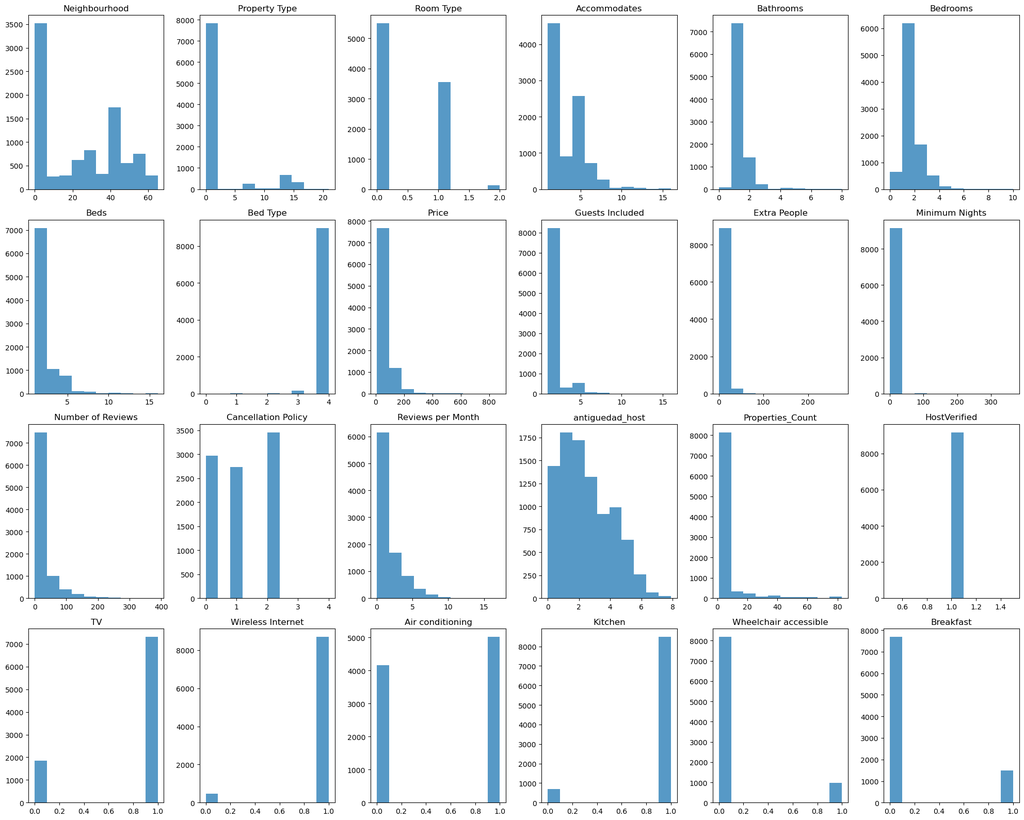

```python
# Ahora pintamos histogramas para cada clase

import matplotlib.pyplot as plt

plt.figure(figsize=(20,16))

columns_to_plot = df.columns.tolist()

num_plots = min(len(columns_to_plot), 24)

for i in range(num_plots):
    plt.subplot(4, 6, i + 1)
    column = columns_to_plot[i]
    plt.hist(df[column], density=0, alpha=0.75)
    plt.title(column)

plt.tight_layout()
plt.show()
```

```python
print('Bed Type')
print(df['Bed Type'].value_counts())  # Parece que casi todas las camas son del mismo tipo. Puede que no sea interesante
print('Guests Included')
print(df['Guests Included'].value_counts())
print('Extra People')
print(df['Extra People'].value_counts())
print('Minimum Nights')
print(df['Minimum Nights'].value_counts())
print('HostVerified')
print(df['HostVerified'].value_counts()) # Todos los valores son 1, así que tampoco aporta.
print('Wireless Internet')
print(df['Wireless Internet'].value_counts()) # Prácticamente todos tiene Wifi, así que no la incluiremos
print('Kitchen')
print(df['Kitchen'].value_counts()) # Cerca del 95% tienen derecho a cocina, la excluiremos también
print('Wheelchair accessible')
print(df['Wheelchair accessible'].value_counts())
print('Breakfast')
print(df['Breakfast'].value_counts())
print('Number of Reviews')
print(df['Number of Reviews'].value_counts())
```

```
Bed Type
4    8980
3     155
2      24
1      11
0       4
Name: Bed Type, dtype: int64
Guests Included
1     5994
2     2238
4      467
3      291
6       76
5       55
7       20
```

[output cut: 130 more lines]

```python
df.drop(['Bed Type', 'HostVerified', 'Wireless Internet', 'Kitchen'], axis = 1, inplace = True)
```

```python
# Revisando los histogramas y value_counts, parece que podríamos generar algunas nuevas varibles que pueden tener relación

df['bed_bath_rooms']   = df['Bedrooms']*df['Bathrooms']
df['guests_extra_people']   = df['Guests Included']*df['Extra People']
df['properties_review']   = df['Properties_Count']*df['Number of Reviews']
```